# Machine Learning - Course Project

Carlos Ochoa

6 de junio de 2019

## Abstract

The pourpose of this exercise is to develop a predictive algorithm that accurately identifies how well 5 different activities are performed, using different biometric measures collected by means of wearables. First, we inspect the dataset and identify the most suitable predictors to be used in the solution. Then we tried different aproaches to predict activities. Finally, we select the most convenient one.

## Data exploration

We have at our disposal two different datasets (training and testing). Both datasets have 160 different variables, but while the training dataset contains the target variables (classe = manner in which the exercise was made), the testing dataset contains instead the problem_id variable that identifies the user to be predicted.

The testing dataset does not contain the outcome, so we cannot use it to measure the out-of-sample performance. To overcome this difficulty, we split the training dataset in two datasets: training and validation. The validation dataset will be used only to estimate the out-of-sample accuracy of the algorithm.

```r
#Loading libraries
library(caret)
library(AppliedPredictiveModeling)
library(varhandle)
library(knitr)
#Reading and splitting dataset
set.seed(44323)
training <- read.csv("pml-training.csv")
testing <- read.csv("pml-testing.csv")
inTrain = createDataPartition(training$classe, p = 3/4)[[1]]
validation = training[-inTrain,]
training = training[ inTrain,]
```

## Data processing

After an inspection of the dataset, we can take some measures to facilitate the prediction task:

- The variables 1 to 7 seem irrelevant for our purpose (user identity, timestamp,…), at least for the degree of sofistication we want. We delete such variables from our dataset.
- All the remaining predictors can be converted to numerical variables. By doing so we help the algorithms to work faster and we can use Principal Components Analysis.
- Some predictors have a lot of missing values. This will difficult the execution of some algorithms, so we impute missing values using a knn imputation. We also center and scale variables.
- We execute a Principal Component Analysis to reduce the large amount of predictors. We create 2 different datasets, retaining components up to 80% (color red in the plot) and 95% of the variance (color blue). These reduced datasets have been used to explore the best predictive algorithm, but the final version does not use PCA. However, working with a reduced number of predictors help to make decisions regarding the algorithm to be used, without long waiting times.

```r
#Deleting first 7 col
training<-training[,-c(1:7)]
validation<-validation[,-c(1:7)]
testing<-testing[,-c(1:7)]

#Remove predicted variable (classe) + problem_id variable
training.predicted<-training[,"classe"]
validation.predicted<-validation[,"classe"]
testing.problemid<-testing[,"problem_id"]
training<-subset(training,select=-classe)
validation<-subset(validation,select=-classe)
testing<-subset(testing,select=-problem_id)

#Transforming into numerical
training<-sapply(training,as.numeric)
validation<-sapply(validation,as.numeric)
testing<-sapply(testing,as.numeric)

#Size of each dataset
dim(training)
```

```
## [1] 14718   152
```

```r
dim(validation)
```

```
## [1] 4904  152
```

```r
dim(testing)
```

```
## [1]  20 152
```

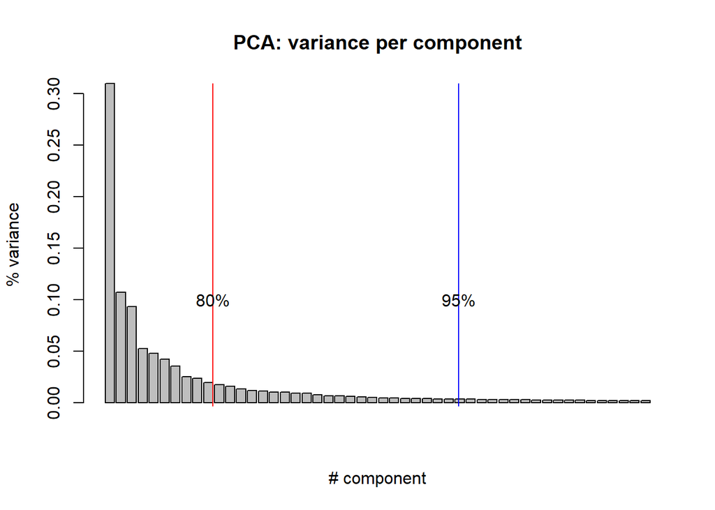

```
## numeric(0)
```

```r
#Imputation, scaling, centering
preProc<-preProcess(training,method=c("center","scale","knnImpute"))
training.processed<-predict(preProc,training)

#Principal analysis component, only on numerical + integer variables
prComp<-prcomp(training.processed)
cum.variance<-cumsum( prComp$sdev^2/sum(prComp$sdev^2))
num.components80<-sum(cum.variance<0.8)
num.components95<-sum(cum.variance<0.95)

training.prcomp80 <- prComp$x[,1:num.components80]
training.prcomp95 <- prComp$x[,1:num.components95]

barplot((prComp$sdev^2/sum(prComp$sdev^2))[1:50],xlab="# component",ylab="% variance", main="PCA: variance per component") +
  abline(v=num.components80, col="red") +
  abline(v=num.components95, col="blue") +
  text(num.components80,0.1,"80%") +
  text(num.components95,0.1,"95%")
```

## Model selection

Up to this point we have several training datasets, with different processing methods. And we want to explore different predicting algorithms.

Training datasets:

- Training.processed: all the variables converted to numerical.
- Training.prcomp80: PCA components retained up to 80% of variance.
- Training.prcomp95: Idem but 95% of variance.

Models to be explored:

- Rpart: CART Tree model.
- Rf: Random forest.
- Lda: Linear discriminant analysis.

For each combination, a model is trained and its accuracy evaluated for the training set. Then, the out-of-sample accuracy is evaluated with the validation set. To do so, the validation set is processed in the same way than the training set.

```r
#Model: cart
mod.cart<-train(training.processed,training.predicted, method="rpart")
mod.cart80<-train(training.prcomp80,training.predicted, method="rpart")
mod.cart95<-train(training.prcomp95,training.predicted, method="rpart")

#Model: rf
mod.rf<-train(training.processed,training.predicted, method="rf")
mod.rf80<-train(training.prcomp80,training.predicted, method="rf")
mod.rf95<-train(training.prcomp95,training.predicted, method="rf")

#Model: lda
mod.lda<-train(training.processed,training.predicted, method="lda")
mod.lda80<-train(training.prcomp80,training.predicted, method="lda")
mod.lda95<-train(training.prcomp95,training.predicted, method="lda")

#Validation processing
validation.processed<-predict(preProc,validation)
prCompValidation<-predict(prComp,validation.processed)
validation.prcomp80 <- prCompValidation[,1:num.components80]
validation.prcomp95 <- prCompValidation[,1:num.components95]

#Calculate accuracy on training data and validation data
acc.training.cart<-c(
  max(mod.cart$results$Accuracy),
  max(mod.cart80$results$Accuracy),
  max(mod.cart95$results$Accuracy)
)

acc.validation.cart<-c(
  mean(validation.predicted==predict(mod.cart,validation.processed)),
  mean(validation.predicted==predict(mod.cart80,validation.prcomp80)),
  mean(validation.predicted==predict(mod.cart95,validation.prcomp95))
)

acc.training.rf<-c(
  max(mod.rf$results$Accuracy),
  max(mod.rf80$results$Accuracy),
  max(mod.rf95$results$Accuracy)
)

acc.validation.rf<-c(
  mean(validation.predicted==predict(mod.rf,validation.processed)),
  mean(validation.predicted==predict(mod.rf80,validation.prcomp80)),
  mean(validation.predicted==predict(mod.rf95,validation.prcomp95))
)

acc.training.lda<-c(
  max(mod.lda$results$Accuracy),
  max(mod.lda80$results$Accuracy),
  max(mod.lda95$results$Accuracy)
)

acc.validation.lda<-c(
  mean(validation.predicted==predict(mod.lda,validation.processed)),
  mean(validation.predicted==predict(mod.lda80,validation.prcomp80)),
  mean(validation.predicted==predict(mod.lda95,validation.prcomp95))
)
```

A summary of the accuracy of each method, estimated by caret with the training data and with the validation data set, is shown below.

```r
library(knitr)

accuracy.summary <- data.frame(
  c("Data processed","PCA 80%","PCA 95"),
  acc.training.cart,acc.validation.cart,
  acc.training.rf,acc.validation.rf,
  acc.training.lda,acc.validation.lda
)
names(accuracy.summary)<-c("Data",
                           "Accuracy training Cart",
                           "Accuracy validation Cart",
                           "Accuracy training Rf",
                           "Accuracy validation Rf",
                           "Accuracy training lda",
                           "Accuracy validation Lda")

kable(accuracy.summary,caption="Accuracy summary for each model and data processing", digits=4)
```

Accuracy summary for each model and data processing

| Data | Accuracy training Cart | Accuracy validation Cart | Accuracy training Rf | Accuracy validation Rf | Accuracy training lda | Accuracy validation Lda |
| --- | --- | --- | --- | --- | --- | --- |
| Data processed | 0.5321 | 0.4947 | 0.9897 | 0.9920 | 0.7066 | 0.7131 |
| PCA 80% | 0.3568 | 0.3597 | 0.9345 | 0.9555 | 0.4268 | 0.4254 |
| PCA 95 | 0.3779 | 0.3844 | 0.9514 | 0.9653 | 0.5354 | 0.5481 |

Results show that the processing without PCA and the model RF are the best combination. For such model, we elaborate a confusion matrix to see if we are performing differently in each one of the 5 predicted classes.

```r
library(caret)
library(knitr)
confMat <- confusionMatrix(
  validation.predicted,
  predict(mod.rf,validation.processed)
)

kable(confMat$table,caption="Confusion matrix")
```

Confusion matrix

|  | A | B | C | D | E |
| --- | --- | --- | --- | --- | --- |
| A | 1394 | 0 | 1 | 0 | 0 |
| B | 8 | 938 | 3 | 0 | 0 |
| C | 0 | 5 | 843 | 7 | 0 |
| D | 0 | 0 | 12 | 791 | 1 |
| E | 0 | 1 | 1 | 0 | 899 |

We also print the most relevant predictors for the algoritm.

```r
varImp(mod.rf)
```

```
## ROC curve variable importance
##
##   variables are sorted by maximum importance across the classes
##   only 20 most important variables shown (out of 152)
##
##                        A       B     C      D       E
## pitch_forearm     63.677 100.000 67.86 63.677 100.000
## accel_forearm_x   41.784  83.636 41.78 41.784  83.636
## magnet_arm_x      54.286  77.909 67.36 54.286  77.909
## magnet_arm_y      39.237  76.574 69.65 39.237  76.574
## magnet_forearm_x  39.580  73.741 35.49 35.495  73.741
## pitch_dumbbell    53.048  53.048 53.05 73.371  43.026
## accel_arm_x       52.399  72.460 62.05 52.399  72.460
## magnet_dumbbell_x 67.451  67.451 67.45 67.451  50.815
## magnet_belt_y     16.008  11.905 65.95 11.905  16.008
## magnet_dumbbell_y 45.287  45.287 45.29 63.074  44.443
## roll_dumbbell     42.708  50.325 29.35 62.199  50.325
## accel_dumbbell_x  57.526  57.526 57.53 58.956  47.450
## magnet_dumbbell_z 55.855  35.896 53.40 23.300  55.855
## magnet_arm_z      52.501  52.501 52.50 52.501  38.881
## pitch_arm         27.514  41.875 50.57 27.514  41.875
## magnet_belt_z      3.544   3.859 48.92  2.219   3.859
## roll_belt         12.378  10.310 46.49 10.310  12.378
## accel_dumbbell_z  46.012  46.012 46.01 46.012  18.229
## yaw_dumbbell      22.655  22.655 22.65 43.512  12.817
## total_accel_arm   33.857  41.765 34.82 18.678  41.765
```

## Prediction on testing dataset

```r
#Testing processing
testing.processed<-predict(preProc,testing)
prCompTesting<-predict(prComp,testing.processed)

prediction.testing<-data.frame(
  problem_id=testing.problemid,
  prediction=predict(
    mod.rf,
    testing.processed)
)

kable(prediction.testing,caption="Prediction")
```

Prediction

| problem_id | prediction |
| --- | --- |
| 1 | C |
| 2 | B |
| 3 | B |
| 4 | A |
| 5 | C |
| 6 | E |
| 7 | D |
| 8 | D |
| 9 | A |
| 10 | A |
| 11 | B |
| 12 | D |
| 13 | B |
| 14 | A |
| 15 | B |
| 16 | B |
| 17 | A |
| 18 | B |
| 19 | B |
| 20 | B |